# Basic statistics for health research - week 6, ex. 1

Benjamin Skov Kaas-Hansen

18/3/2021

### Prep and setup

```r
library(tidyverse)
theme_set(theme_minimal())

pretty_estimates <- function(m) { # m: model object
    cbind(Est. = m$coefficients, confint(m))
}
```

# Notes and precautions

Four assumptions need to be satisfied for a linear regression to be legit:

- Linear relationship (eyeball it or use a smoother to see if the trend is approximately linear; with few observations numerical tests fail because they’re underpowered so wouldn’t be able to reject the hypothesis even if it were false)
- Independent observations (if not, go for hierarchical regression)
- Homogeneity of variance (homoscedacity): no “trumpet” of observations around line (variance should be the same throughout the range of the indepedent variable; in biological data this is often violated, because e.g. with a larger body your brain size has more “wiggle” room often leading to larger variance for larger bodies, or if with bounded scales [e.g. ranking something on a scale between 0 and 100])
- Residuals are normally distributed (so most observations should be closer to the regression line, and fewer far away)

# Brain

```r
mus <- read_delim("http://publicifsv.sund.ku.dk/~lts/basal/data/brain.txt", delim = " ")
```

### Q1: Look at litter and brain scatter

Seems to be a fairly linear negative relationship: larger litters, smaller brains. Note the “chunking” of observations: litter size is an integer, and for each value of litter size we have exactly two observations. This is of course artificial and a consequence of the study design which is important (discussed later).

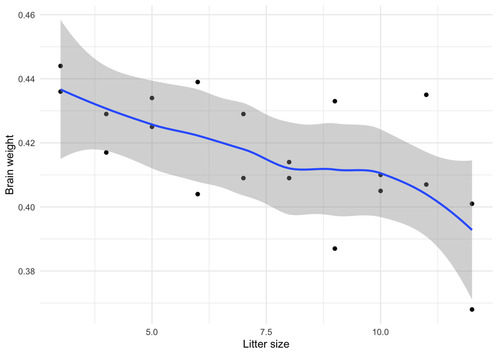

```r
ggplot(mus, aes(litter, brain)) +
    geom_point() +
    geom_smooth(method = "loess") +
    labs(x = "Litter size", y = "Brain weight")
```

### Q2: Brain weight ~ litter size

First, fit model and get results.

```r
model1 <- lm(brain ~ litter, data = mus)
summary(model1)
```

```
##
## Call:
## lm(formula = brain ~ litter, data = mus)
##
## Residuals:
##       Min        1Q    Median        3Q       Max
## -0.030600 -0.006742  0.000183  0.007650  0.032367
##
## Coefficients:
##              Estimate Std. Error t value Pr(>|t|)
## (Intercept)  0.447000   0.009625  46.443  < 2e-16 ***
## litter      -0.004033   0.001198  -3.366  0.00344 **
## ---
## Signif. codes:  0 '***' 0.001 '**' 0.01 '*' 0.05 '.' 0.1 ' ' 1
##
## Residual standard error: 0.01539 on 18 degrees of freedom
## Multiple R-squared:  0.3862, Adjusted R-squared:  0.3521
## F-statistic: 11.33 on 1 and 18 DF,  p-value: 0.003445
```

```r
pretty_estimates(model1)
```

```
##                     Est.        2.5 %      97.5 %
## (Intercept)  0.447000000  0.426779125  0.46722087
## litter      -0.004033333 -0.006551127 -0.00151554
```

Scatterplot with overlain linear regression

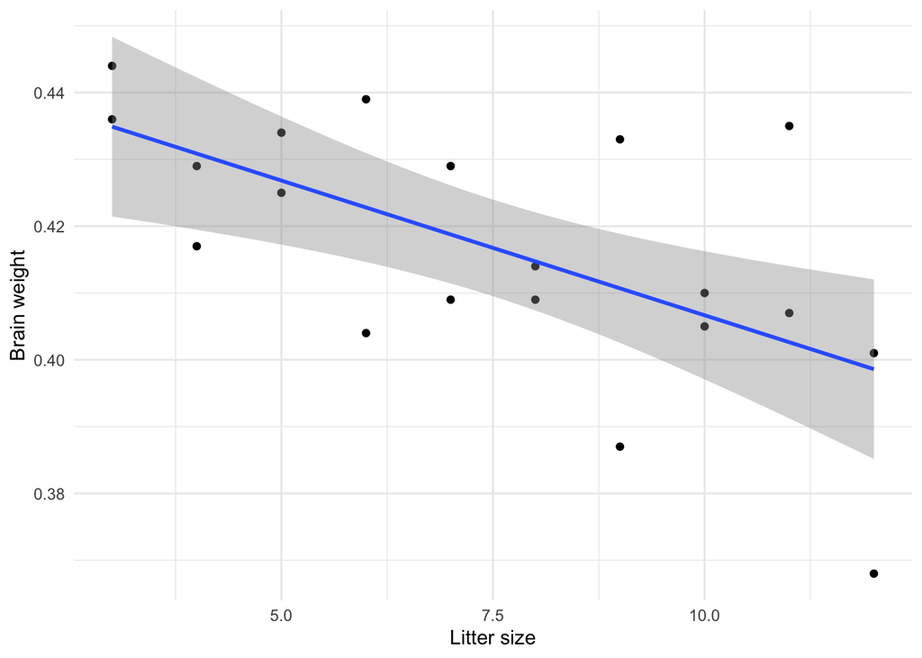

```r
ggplot(mus, aes(litter, brain)) +
    geom_point() +
    geom_smooth(method = "lm") +
    labs(x = "Litter size", y = "Brain weight")
```

#### a. Expected brain weight for litter size 5

Because we’re talking about the expected brain weight (so, the mean in a population), we use the `confidence` interval, as we’re interested in an estimate of the confidence. NB! The Danish sentence is actually ambiguous, depending on which word you stress, so one could also read it to mean the weight of a specific mouse, rendering the prediction interval appropriate.

```r
litter5 <- data.frame(litter = 5)
predict(model1, newdata = litter5, interval = "confidence")
```

```
##         fit       lwr       upr
## 1 0.4268333 0.4172459 0.4364208
```

#### b. Is a 0.4 g brain unusual?

With this phrasing, we’re interested in a particular mouse from a litter of size 5. So for that, we need the `prediction` interval, because the prediction for a specific mouse is more uncertain than the mean in a larger population. The `prediction` interval uses the residual variance because this captures (and expresses) unexplained randomness, and so the uncertainty of a prediction for a specific mouse should reflect this. 0.4 g is just inside the prediction interval, so unusual but not far out.

```r
predict(model1, newdata = litter5, interval = "prediction")
```

```
##         fit       lwr       upr
## 1 0.4268333 0.3931005 0.4605661
```

### Q3: Brain weight ~ body weight

```r
model2 <- lm(brain ~ body, data = mus)
summary(model2)
```

```
##
## Call:
## lm(formula = brain ~ body, data = mus)
##
## Residuals:
##       Min        1Q    Median        3Q       Max
## -0.024679 -0.004910 -0.001179  0.007464  0.024161
##
## Coefficients:
##             Estimate Std. Error t value Pr(>|t|)
## (Intercept) 0.335568   0.017318  19.377 1.66e-13 ***
## body        0.010479   0.002203   4.756 0.000158 ***
## ---
## Signif. codes:  0 '***' 0.001 '**' 0.01 '*' 0.05 '.' 0.1 ' ' 1
##
## Residual standard error: 0.01308 on 18 degrees of freedom
## Multiple R-squared:  0.5569, Adjusted R-squared:  0.5323
## F-statistic: 22.62 on 1 and 18 DF,  p-value: 0.0001578
```

```r
pretty_estimates(model2)
```

```
##                  Est.      2.5 %     97.5 %
## (Intercept) 0.3355681 0.29918471 0.37195158
## body        0.0104790 0.00585007 0.01510793
```

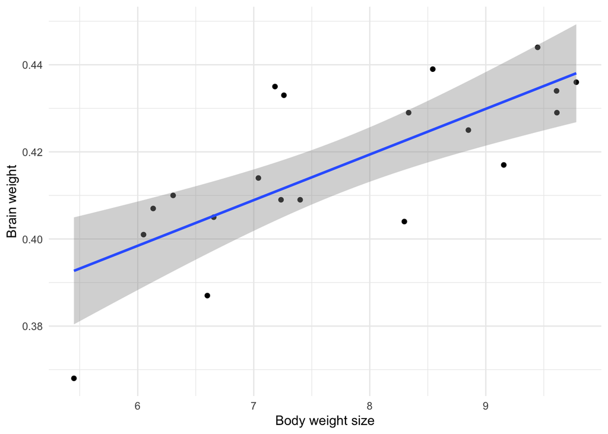

```r
ggplot(mus, aes(body, brain)) +
    geom_point() +
    geom_smooth(method = "lm") +
    labs(x = "Body weight size", y = "Brain weight")
```

### Q4: Correlation, litter size and body weight

Pearson assumes bivariate Gaussian distribution, so when you have non-random sampling of one of the variables (litter here, as we have to observation by litter size, so non-random) Pearson is a no-go. In general, don’t do it: use linear regression instead.

Correlation in general goes up when the variance of the x variable goes up, so it’s generally not useful as you can this way design your data collection to artificially amplify correlation.

```r
cor.test(mus$litter, mus$body)
```

```
##
##  Pearson's product-moment correlation
##
## data:  mus$litter and mus$body
## t = -13.615, df = 18, p-value = 6.443e-11
## alternative hypothesis: true correlation is not equal to 0
## 95 percent confidence interval:
##  -0.9822552 -0.8869040
## sample estimates:
##        cor
## -0.9547218
```

```r
cor.test(mus$litter, mus$body, method = "spearman")
```

```
##
##  Spearman's rank correlation rho
##
## data:  mus$litter and mus$body
## S = 2594.8, p-value = 1.306e-10
## alternative hypothesis: true rho is not equal to 0
## sample estimates:
##        rho
## -0.9509502
```

By the way, if you square the Pearson correlation coefficient, you obtain the R-squared, making R-squared as useless as Pearson’s coefficient.

### Q5: Body weight ~ litter size

Give biological explanation for the findings.

```r
model3 <- lm(body ~ litter, data = mus)
summary(model3)
```

```
##
## Call:
## lm(formula = body ~ litter, data = mus)
##
## Residuals:
##      Min       1Q   Median       3Q      Max
## -0.56772 -0.29649 -0.03498  0.20320  0.98025
##
## Coefficients:
##             Estimate Std. Error t value Pr(>|t|)
## (Intercept) 11.05642    0.26027   42.48  < 2e-16 ***
## litter      -0.44124    0.03241  -13.62 6.44e-11 ***
## ---
## Signif. codes:  0 '***' 0.001 '**' 0.01 '*' 0.05 '.' 0.1 ' ' 1
##
## Residual standard error: 0.4163 on 18 degrees of freedom
## Multiple R-squared:  0.9115, Adjusted R-squared:  0.9066
## F-statistic: 185.4 on 1 and 18 DF,  p-value: 6.443e-11
```

```r
cor.test(mus$litter, mus$body)$estimate^2 # same as R-squared
```

```
##       cor
## 0.9114938
```

```r
pretty_estimates(model3)
```

```
##                   Est.      2.5 %     97.5 %
## (Intercept) 11.0564182 10.5096026 11.6032338
## litter      -0.4412424 -0.5093289 -0.3731559
```

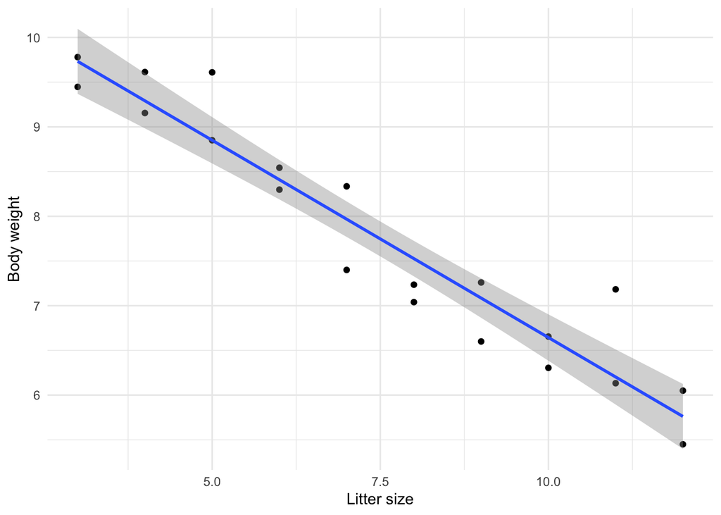

```r
ggplot(mus, aes(litter, body)) +
    geom_point() +
    geom_smooth(method = "lm") +
    labs(x = "Litter size", y = "Body weight")
```

```r
predict(model3, newdata = litter5, interval = "confidence")
```

```
##        fit     lwr      upr
## 1 8.850206 8.59094 9.109472
```

```r
predict(model3, newdata = litter5, interval = "prediction")
```

```
##        fit      lwr      upr
## 1 8.850206 7.937999 9.762413
```

### Q6: Multiple linear regression

```r
model4 <- lm(brain ~ litter + body, data = mus)
summary(model4)
```

```
##
## Call:
## lm(formula = brain ~ litter + body, data = mus)
##
## Residuals:
##        Min         1Q     Median         3Q        Max
## -0.0230428 -0.0098897  0.0006377  0.0092065  0.0180602
##
## Coefficients:
##             Estimate Std. Error t value Pr(>|t|)
## (Intercept) 0.178771   0.075213   2.377  0.02947 *
## litter      0.006671   0.003128   2.132  0.04785 *
## body        0.024260   0.006769   3.584  0.00229 **
## ---
## Signif. codes:  0 '***' 0.001 '**' 0.01 '*' 0.05 '.' 0.1 ' ' 1
##
## Residual standard error: 0.01196 on 17 degrees of freedom
## Multiple R-squared:  0.6504, Adjusted R-squared:  0.6093
## F-statistic: 15.81 on 2 and 17 DF,  p-value: 0.000132
```

```r
pretty_estimates(model4)
```

```
##                    Est.        2.5 %     97.5 %
## (Intercept) 0.178770659 2.008551e-02 0.33745581
## litter      0.006671233 7.088313e-05 0.01327158
## body        0.024260057 9.978796e-03 0.03854132
```

#### a. Expected brain weight for litter size 5 and body weight 10

```r
litter5_body10 <- data.frame(litter = 5, body = 10)
predict(model4, newdata = litter5_body10, interval = "confidence")
```

```
##         fit       lwr       upr
## 1 0.4547274 0.4366846 0.4727702
```

```r
predict(model4, newdata = litter5_body10, interval = "prediction")
```

```
##         fit       lwr       upr
## 1 0.4547274 0.4237155 0.4857393
```

#### b. Explain difference from Q2a

For litters of size 5, a body weight of 10 g. is quite unusual, as per the prediction interval:

```r
predict(model3, newdata = litter5, interval = "prediction")
```

```
##        fit      lwr      upr
## 1 8.850206 7.937999 9.762413
```

–and so, the brain weight in such a (large) mouse is expected to also be higher.

```r
predict(model1, newdata = litter5, interval = "prediction")
```

```
##         fit       lwr       upr
## 1 0.4268333 0.3931005 0.4605661
```

```r
predict(model4, newdata = litter5_body10, interval = "prediction")
```

```
##         fit       lwr       upr
## 1 0.4547274 0.4237155 0.4857393
```

### Q7: Biological difference of coefficients in models 1 and 3

There’s a nice description in the “opgavebesvarelse”.

# Biomasse

```r
bio <- read_delim("http://publicifsv.sund.ku.dk/~lts/basal/data/biomasse.txt", delim = " ")
```

### Q1: Might the relationship be linear?

Use a scatter plot. It could be conceived as potentially linear, but it does seem a little sigmoid.

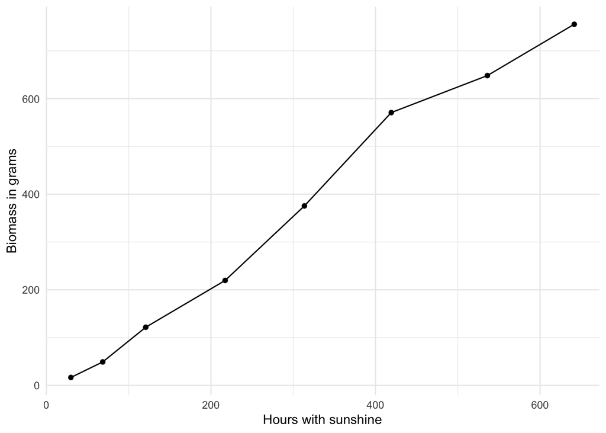

```r
ggplot(bio, aes(sol, biomass)) +
    geom_line() +
    geom_point() +
    labs(x = "Hours with sunshine", y = "Biomass in grams")
```

### Q2: Intercept and slope

Particularly, can the sloe be considered be to 1? Nope, see summary.

```r
model1 <- lm(biomass ~ sol, data = bio)
summary(model1)
```

```
##
## Call:
## lm(formula = biomass ~ sol, data = bio)
##
## Residuals:
##     Min      1Q  Median      3Q     Max
## -31.052 -14.738  -4.175   5.488  66.428
##
## Coefficients:
##              Estimate Std. Error t value Pr(>|t|)
## (Intercept) -27.56895   19.84220  -1.389    0.214
## sol           1.26925    0.05503  23.063 4.36e-07 ***
## ---
## Signif. codes:  0 '***' 0.001 '**' 0.01 '*' 0.05 '.' 0.1 ' ' 1
##
## Residual standard error: 32.65 on 6 degrees of freedom
## Multiple R-squared:  0.9888, Adjusted R-squared:  0.987
## F-statistic: 531.9 on 1 and 6 DF,  p-value: 4.355e-07
```

```r
pretty_estimates(model1)
```

```
##                   Est.      2.5 %    97.5 %
## (Intercept) -27.568952 -76.121061 20.983157
## sol           1.269246   1.134583  1.403909
```

We could find the p value for $H_0: \beta = 1$ by instead using $H_0: \beta - 1 = 0$, and find the corresponding t value with its p value.

```r
tibble(t_value = (coef(model1)[2] - 1)/coef(summary(model1))[2, 2], # = (coef - 1)/se_coef)
       p_value = 2 * (1 - pt(t_value, summary(model1)$df[2])))
```

```
## # A tibble: 1 x 2
##   t_value p_value
##     <dbl>   <dbl>
## 1    4.89 0.00273
```

NB! It’s misleading to do such a NHST for a specific value after seeing the data. Such tests must be devised before data collection.

Visualing the data with the linear fit:

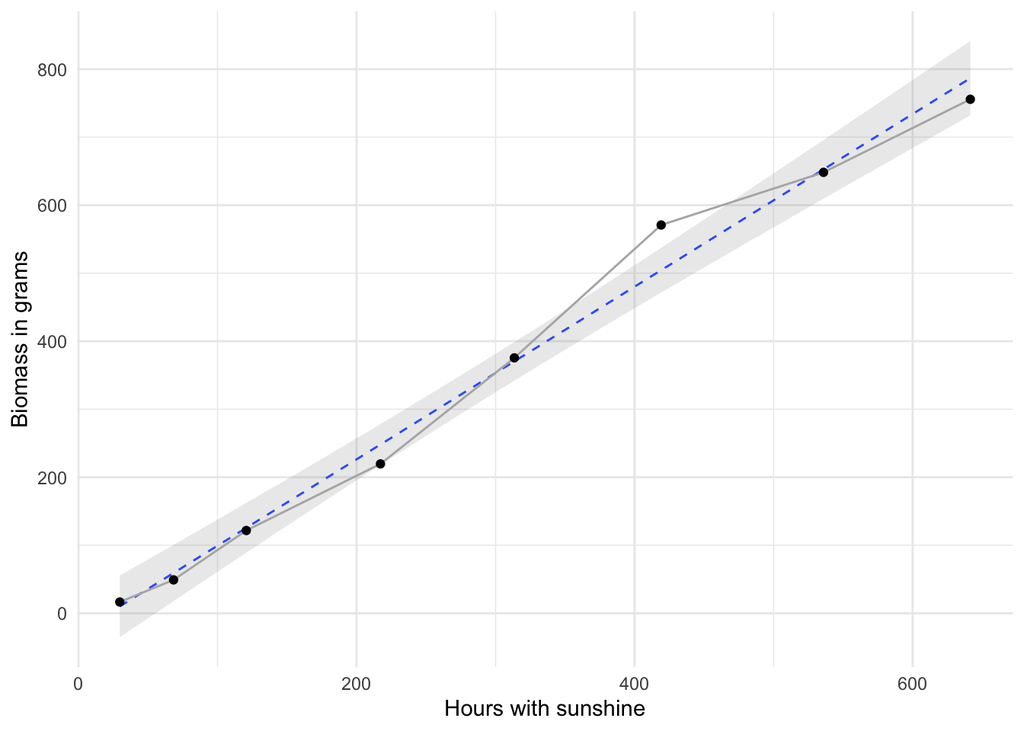

```r
ggplot(bio, aes(sol, biomass)) +
    geom_smooth(method = "lm", alpha = 0.2, linetype = 2, size = 0.5) +
    geom_line(colour = "grey70", size = 0.5) +
    geom_point() +
    labs(x = "Hours with sunshine", y = "Biomass in grams")
```

### Q3: Could intercept be 0? And what happens to the slope?

```r
model2 <- lm(biomass ~ sol - 1, data = bio)
summary(model2)
```

```
##
## Call:
## lm(formula = biomass ~ sol - 1, data = bio)
##
## Residuals:
##     Min      1Q  Median      3Q     Max
## -42.572 -26.359 -18.987  -1.848  64.924
##
## Coefficients:
##     Estimate Std. Error t value Pr(>|t|)
## sol  1.20705    0.03408   35.42 3.71e-09 ***
## ---
## Signif. codes:  0 '***' 0.001 '**' 0.01 '*' 0.05 '.' 0.1 ' ' 1
##
## Residual standard error: 34.75 on 7 degrees of freedom
## Multiple R-squared:  0.9945, Adjusted R-squared:  0.9937
## F-statistic:  1255 on 1 and 7 DF,  p-value: 3.712e-09
```

```r
pretty_estimates(model2)
```

```
##         Est.   2.5 %   97.5 %
## sol 1.207054 1.12647 1.287637
```

```r
pretty_estimates(model2)
```

```
##         Est.   2.5 %   97.5 %
## sol 1.207054 1.12647 1.287637
```

```r
pretty_estimates(model1)
```

```
##                   Est.      2.5 %    97.5 %
## (Intercept) -27.568952 -76.121061 20.983157
## sol           1.269246   1.134583  1.403909
```

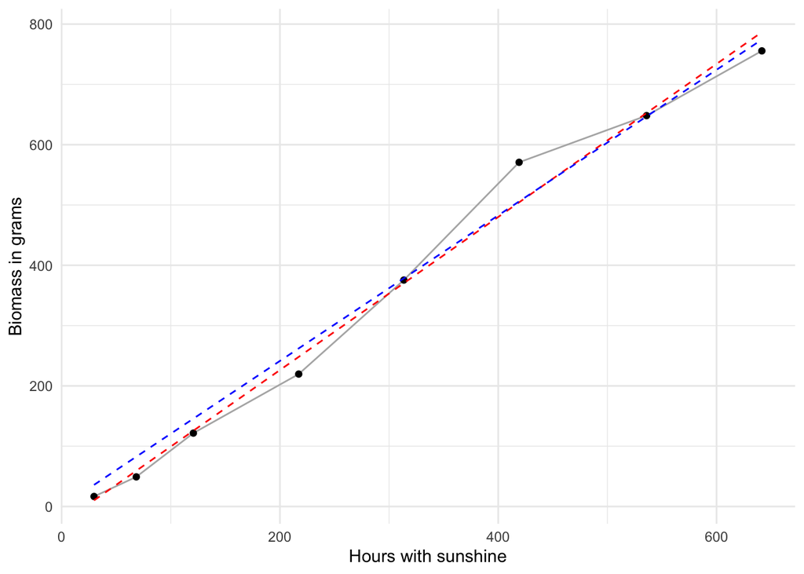

```r
ggplot(bio, aes(sol, biomass)) +
    geom_line(colour = "grey70", size = 0.5) +
    geom_point() +
    geom_smooth(method = "lm", alpha = 0.2, linetype = 2, size = 0.5, colour = "red", se = FALSE) +
    geom_smooth(method = "lm", formula = y ~ x - 1, alpha = 0.2, linetype = 2, size = 0.5, colour = "blue", se = FALSE)  +
    labs(x = "Hours with sunshine", y = "Biomass in grams")
```

### Q4: 95% confidence interval for estimated production when cum. hours of sunshine reaches 200

The no-intercept model predicts higher yield at 200 hours of sunshine because this point is shifted upwards compared with the normal linear model. The two lines cross around sol = 430.

```r
sol200 <- data.frame(sol = 200)

predict(model2, newdata = sol200, interval = "prediction")
```

```
##        fit      lwr      upr
## 1 241.4107 157.6682 325.1533
```

```r
predict(model1, newdata = sol200, interval = "prediction")
```

```
##        fit     lwr      upr
## 1 226.2803 140.616 311.9445
```

```r
predict(model2, newdata = sol200, interval = "confidence")
```

```
##        fit     lwr      upr
## 1 241.4107 225.294 257.5274
```

```r
predict(model1, newdata = sol200, interval = "confidence")
```

```
##        fit      lwr      upr
## 1 226.2803 195.3685 257.1921
```

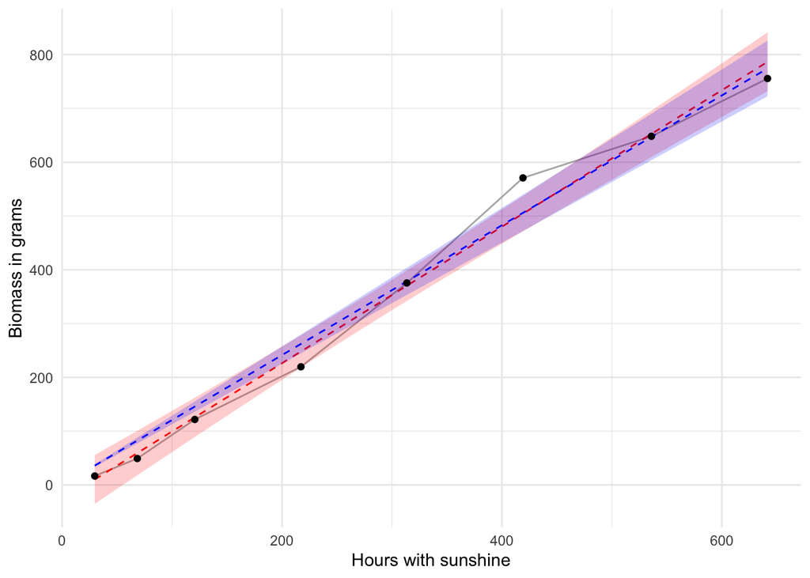

```r
ggplot(bio, aes(sol, biomass)) +
    geom_line(colour = "grey70", size = 0.5) +
    geom_smooth(method = "lm", alpha = 0.2, linetype = 2, size = 0.5, colour = "red", fill = "red") +
    geom_smooth(method = "lm", formula = y ~ x - 1, alpha = 0.2, linetype = 2, size = 0.5, colour = "blue", fill = "blue") +
    geom_point() +
    labs(x = "Hours with sunshine", y = "Biomass in grams")
```